# HW - Linear Regression

Shyam BV

November 13, 2016

### 7.24 Nutrition at Starbucks, Part I.

The scatterplot below shows the relationship between the number of calories and amount of carbohydrates (in grams) Starbucks food menu items contain. Since Starbucks only lists the number of calories on the display items, we are interested in predicting the amount of carbs a menu item has based on its calorie content.

```r
starbucks <- read.csv("https://raw.githubusercontent.com/jbryer/DATA606Fall2016/master/Data/Data%20from%20openintro.org/Ch%207%20Exercise%20Data/starbucks.csv",header = TRUE,sep=",",stringsAsFactors = FALSE)
```

**(a) Describe the relationship between number of calories and amount of carbohydrates (in grams) that Starbucks food menu items contain.**

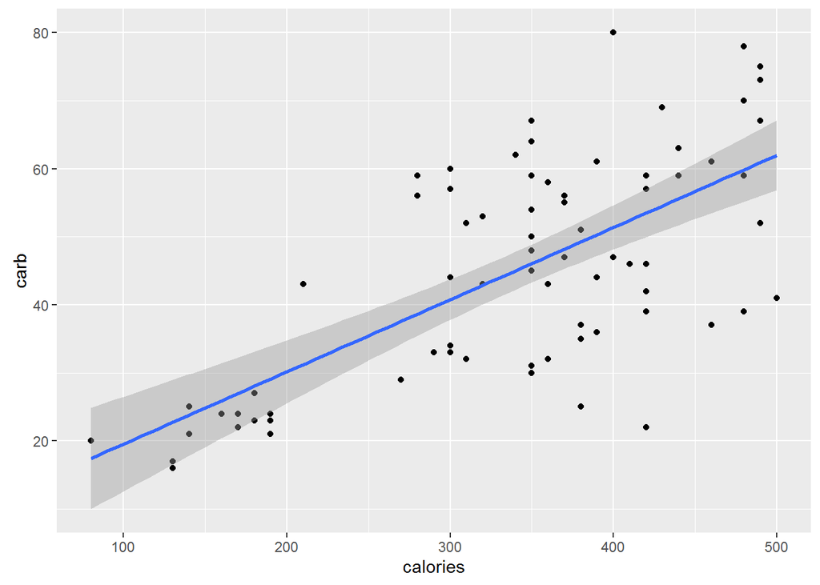

```r
ggplot(starbucks,aes(x=calories,y=carb)) + geom_point() + geom_smooth(method="lm")
```

```r
cor(starbucks$calories,starbucks$carb)
```

```
## [1] 0.674999
```

**(b) In this scenario, what are the explanatory and response variables?**

In this scenario, the explanatory variable is `Calories` and the response variable is `Carb`.

**(c) Why might we want to fit a regression line to these data?**

Because we want to see the historical trend and predict the future outcomes. If the the calories increases, what might be the point estimate of `Carb` level.

**(d) Do these data meet the conditions required for fitting a least squares line?**

### 7.26 Body measurements, Part III.

```r
bdim <- read.delim("https://raw.githubusercontent.com/jbryer/DATA606Fall2016/master/Data/Data%20from%20openintro.org/Ch%207%20Exercise%20Data/bdims.txt",header = TRUE,sep="\t",stringsAsFactors = FALSE)

mean(bdim$sho.gi)
```

```
## [1] 108.1951
```

```r
sd(bdim$sho.gi)
```

```
## [1] 10.37483
```

```r
mean(bdim$hgt)
```

```
## [1] 171.1438
```

```r
sd(bdim$hgt)
```

```
## [1] 9.407205
```

```r
cor(bdim$hgt,bdim$sho.gi)
```

```
## [1] 0.6657353
```

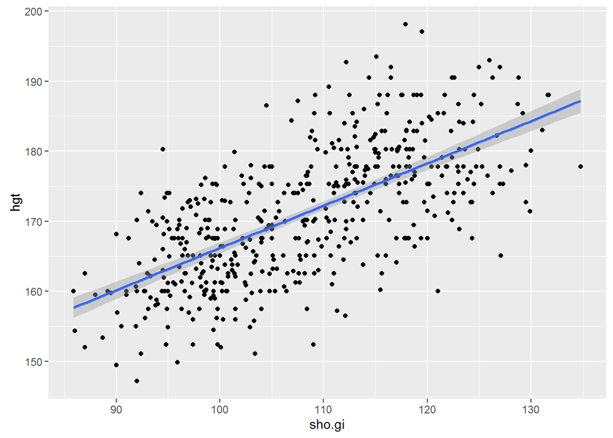

```r
ggplot(bdim,aes(x=sho.gi,y=hgt)) + geom_point() + geom_smooth(method="lm")
```

**(a) Write the equation of the regression line for predicting height.**

```r
p1 <- summary(lm(bdim$hgt~bdim$sho.gi))

#Equation for of regression line predicting height

paste(p1$coefficients[[1]],' + ',p1$coefficients[[2]],'*','Sholders Grim')
```

```
## [1] "105.832461820568  +  0.603644193262076 * Sholders Grim"
```

```r
#Explanation

R = (sd(bdim$hgt)/sd(bdim$sho.gi))*cor(bdim$hgt,bdim$sho.gi)
```

hgt = $\beta_0$ + $\beta_1$ * sho.gi

**(b) Interpret the slope and the intercept in this context.**

```r
Intercept <- p1$coefficients[[1]]
slope <- p1$coefficients[[4]]
```

Intercept means the minimum height when sholder grim is 0. The height will be atleast 105.83 cm if the sholder grim is zero. Slope means for every additional 1 cm increase in sholder grim, there will be 0.603 increase in height.

**(c) Calculate R^2 of the regression line for predicting height from shoulder girth, and interpret it in the context of the application.**

```r
Rsq <- p1$r.squared

R*R
```

```
## [1] 0.3643863
```

**(d) A randomly selected student from your class has a shoulder girth of 100 cm. Predict the height of this student using the model.**

```r
#substitute sholder girth in the linear equation

sho.gi = 100
p1$coefficients[[1]]+p1$coefficients[[2]]*sho.gi
```

```
## [1] 166.1969
```

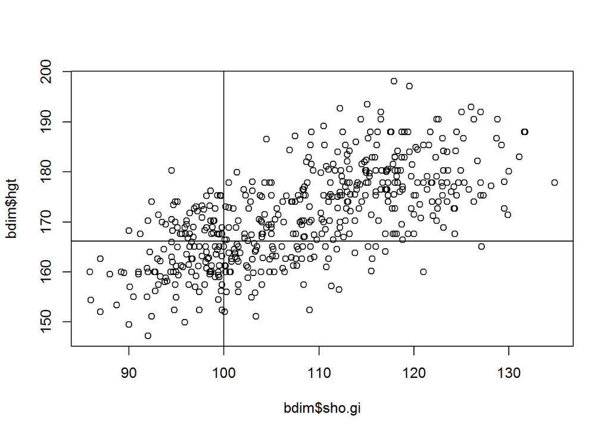

```r
#plot
plot(bdim$sho.gi,bdim$hgt)
abline(v=sho.gi)
abline(h=p1$coefficients[[1]]+p1$coefficients[[2]]*sho.gi)
```

**(e) The student from part (d) is 160 cm tall. Calculate the residual, and explain what this residual means.**

```r
 sholder.grim =(160 -p1$coefficients[[1]])/p1$coefficients[[2]]

residual = (160-100)
```

**(f) A one year old has a shoulder girth of 56 cm. Would it be appropriate to use this linear model to predict the height of this child?**

```r
sho.gi = 56

p1$coefficients[[1]]+p1$coefficients[[2]]*sho.gi
```

```
## [1] 139.6365
```

Above equation shows the height of the one year old is 139.63 cm. Practically this is an extrapolation value. Because the one year old cannot be 4.6 feet. Our model does not calculate the value for 1 year old childeren.

### 7.30 Cats, Part I.

The following regression output is for predicting the heart weight (in g) of cats from their body weight (in kg). The coefficients are estimated using a dataset of 144 domestic cats.

[output not shown]

s = 1.452 $R^2$ = 64.66% $R^2_adj$ = 64.41%

1. Write out the linear model.
2. Interpret the intercept.
3. Interpret the slope.
4. Interpret R2.
5. Calculate the correlation coefficient.